# In-term II, M362M Fall 2020

The first problem is theoretical. *Do not* use R to solve it (but you can use it as a calculator if you want to). Submit your solution either typed up, or hand-written and then scanned. In either case, your submission needs to be a *pdf* file.

The second problem is (mostly) computational. Submit its solution in pdf (knitted from Rmd) just like you would submit your HW. Additionally, **submit the Rmd file you used to knit the pdf**. Just a pdf file without the accompanying Rmd file will not be accepted.

If you have any questions, please post them on Piazza. I will be checking in regularly throughout the day.

### Problem 1

Let $\{X_n\}_{n\in {\mathbb{N}}_0}$ be a simple symmetric random walk.

1. What is the probability that $X$ will reach the level $4$ in the first $10$ steps (i.e., up to and including time $n=10$)?
2. The same as above, but if you know (are given) that $X_2\ne 0$?
3. Let $\tau$ be the first time $X$ hits level $4$ in the first $10$ steps. If that does not happen, i.e., if $X_n<4$ for all $n\leq 10$, we set $\tau=10$. Find ${\mathbb{P}}[\tau=10]$.
4. (extra credit) What is the expected value of the random variable $Y$ given by
   $$\begin{align}
   Y = \begin{cases} 4& \text{ when } M_{10}\geq 4 \\
   X_{10}& \text{ when } M_{10} < 4. \end{cases}
   \end{align}$$
   where, as usual, $M_n = \max(X_0,\dots, X_n)$.

1. This the the same as the probability that the running maximum $M$ of $X$ takes the value $\geq 4$ at time $n=10$. Using out formula for the distribution of $M_{10}$ we get
$$\begin{align}
{\mathbb{P}}[ M_{10} \geq 4] = 1 &- {\mathbb{P}}[M_{10}\leq 3] = 1 - {\mathbb{P}}[ M_{10}=0] - {\mathbb{P}}[M_{10} = 1] - {\mathbb{P}}[ M_{10} = 2] - {\mathbb{P}}[ M_{10}=3]\\
= 1 &- ({\mathbb{P}}[X_{10}=0]+{\mathbb{P}}[X_{10}=1])\\ & -
({\mathbb{P}}[X_{10}=1]+{\mathbb{P}}[X_{10}=2])\\ & -
({\mathbb{P}}[X_{10}=2]+{\mathbb{P}}[X_{10}=3])\\ & -
({\mathbb{P}}[X_{10}=3]+{\mathbb{P}}[X_{10}=4])\\
= 1 &- {\mathbb{P}}[X_{10}=0] - 2{\mathbb{P}}[X_{10}=2] - {\mathbb{P}}[X_{10}=4] =
1 - 2^{-10}\Big( \binom{10}{5} + 2 \binom{10}{4} + \binom{10}{3}\Big)\\
= 1 & - 2^{-10}\Big( 252 + 2 \times 210 + 120 \Big) = 1 - \frac{792}{1024} = \frac{29}{128} \approx 0.2266
\end{align}$$

2. This is a conditional probability. Since ${\mathbb{P}}[X_2\ne 0]= 1 - {\mathbb{P}}[ X_2=0] = 1/2$, it equals to
$$\begin{align}
{\mathbb{P}}[M_{10} \geq 4 | X_2\ne 0] & = {\mathbb{P}}[ M_{10} \geq 4 \text{ and }X_2\ne 0] / {\mathbb{P}}[ X_2\ne 0] =
2 {\mathbb{P}}[ M_{10} \geq 4 \text{ and }X_2 \ne 0] \\
&= 2 \Big( {\mathbb{P}}[M_{10} \geq 4] - {\mathbb{P}}[ M_{10}\geq 4 \text{ and }X_2=0])
\end{align}$$
We have computed ${\mathbb{P}}[ M_{10} \geq 4]$ in the first part of the problem, so it remains to compute ${\mathbb{P}}[ M_{10} \geq 4 \text{ and }X_2=0]$. You can compute this in many ways (by counting trajectories, e.g.), but probably the simplest way is to write it to use the multiplication rule:
$$\begin{align}
{\mathbb{P}}[ M_{10} \geq 4 \text{ and }X_2=0] = {\mathbb{P}}[ M_{10} \geq 4| X_2=0] {\mathbb{P}}[ X_2=0]
\end{align}$$
The second probability is $1/2$, while the first probability is the same as the probability that a random walk *of $8$ steps* reaches the level $4$, i.e. ${\mathbb{P}}[ M_8 \geq 4]$. As above:
$$\begin{align}
{\mathbb{P}}[ M_{8} \geq 4] =
= 1 &- {\mathbb{P}}[X_{8}=0] - 2{\mathbb{P}}[X_{8}=2] - {\mathbb{P}}[X_{8}=4] =
1 - 2^{-8}\Big( \binom{8}{4} + 2 \binom{8}{3} + \binom{8}{2}\Big)\\
= 1 & - \frac{210}{256} = \frac{23}{128} \approx 0.1797
\end{align}$$
All together:
$$\begin{align}
{\mathbb{P}}[M_{10} \geq 4 | X_2\ne 0] &= 2\tfrac{29}{128} - \tfrac{23}{128} = \tfrac{35}{128} \approx 0.2734
\end{align}$$

Equally correct (but a bit less rigorous) is the following reasoning. If $X_2\ne 0$, then $X_2=\pm 2$ with equal probabilities. In the first case, the remaining $8$ steps need to reach the level $4-2=2$ in 8 steps. In the second, the level that needs to be reached in 8 steps is $4- (-2) = 6$. Therefore,
$$\begin{align}
{\mathbb{P}}[ M_{10} \geq 4| M_2 = 0] &= \tfrac{1}{2}{\mathbb{P}}[M_{8} \geq 2] + \tfrac{1}{2}{\mathbb{P}}[ M_{8} \geq 6]]\\
&= \tfrac{1}{2}( 1 - {\mathbb{P}}[ M_8=0] + {\mathbb{P}}[ M_8=1]) + \tfrac{1}{2}( {\mathbb{P}}[M_8=6]+ {\mathbb{P}}[ M_8=7] + {\mathbb{P}}[M_8=8])\\
&= \tfrac{1}{2}( 1 - {\mathbb{P}}[ X_8=0] -{\mathbb{P}}[ X_8=2]) + \tfrac{1}{2}( {\mathbb{P}}[X_8=6]+ {\mathbb{P}}[ M_8=8] + {\mathbb{P}}[M_8=8])\\
& = \tfrac{1}{2}- 2^{-9}( \binom{8}{4} + \binom{8}{3} - \binom{8}{7} - 2) = \frac{35}{128} \approx 0.2734
\end{align}$$
3. We have $\tau\ne 10$ if and only if $M_{9}\geq 4$. Therefore, just like above, we get
$$\begin{align}
{\mathbb{P}}\tau=10] &= 1- {\mathbb{P}}[ \tau\ne 10] = {\mathbb{P}}[ M_9\leq 3] = 2 {\mathbb{P}}[X_9=1 ] + 2{\mathbb{P}}[ X_{9}=3] = 2 \times 2^{-8}
\Big( \binom{9}{5} + \binom{9}{6}\Big) = \frac{105}{128} \approx 0.8203
\end{align}$$

4. Let $\tau$ be the stopping time from part 3. above. Then $Y = X_{\tau}$ and, by Wald’s formula, ${\mathbb{E}}[X_{\tau}] = {\mathbb{E}}[X_1] {\mathbb{E}}[\tau] = 0\times {\mathbb{E}}[\tau] = 0$.

The first version of the problem contained a typo, which made the problem harder. With the typo, where the inequalities in the definition of $Y$ were incorrect $Y$ was defined as follows (we call it $Y'$ to avoid confusion)
$$\begin{align}
Y' = \begin{cases} 4& \text{ when } M_{10}\leq 4 \\
X_{10}& \text{ when } M_{10} > 4. \end{cases}
\end{align}$$
In this case, we need to work a bit harder than above:
$$\begin{align}
{\mathbb{E}}[ Y'] &= 4 {\mathbb{P}}[ M_{10} \geq 4] + {\mathbb{E}}[ X_{10}| M_{10}>4]\\
&= 4 {\mathbb{P}}[ M_{10} \geq 4] + {\mathbb{E}}[X_{10} | M_{10}>4] {\mathbb{P}}[M_{10}>4].
\end{align}$$
The difficult part is the conditional expectation ${\mathbb{E}}[X_{10} |M_{10}>4]$, but we can compute it if we realize the following: the condition $\{M_{10}>4\} = \{M_{10}\geq 5\}$ means that the level $5$ *is* hit at some stopping time $\tau$ which happens strictly before time $n=10$. From $\tau$ onwards, $X$ behaves like a random walk starting at $5$, so its value at time $n=10$ is completely symmetric around the value $5$. In particular, its expected value is $5$. Therefore,
$$\begin{align}
{\mathbb{E}}[Y'] &= 4 {\mathbb{P}}[ M_{10} \geq 4] + 5 {\mathbb{P}}[ M_{10}>4] = 5 - {\mathbb{P}}[M_{10}\leq 4]\\
&= 5 - 2^{-10} \Big( \binom{10}{5} + 2 \binom{10}{4} + 2 \binom{10}{3}\Big)
= \frac{263}{64} \approx 4.11
\end{align}$$

### Problem 2

[figure not shown]

Wonder Woman is walking on a cube. She moves from vertex to vertex along the edges (she never goes onto the cube’s faces). In each step she chooses one of the three neighboring vertices with equal probability and moves there. Once she reaches the vertex opposite the vertex she started from she stops moving and stays there forever.

1. Make a Markov-Chain model of the situation:
   1. Sketch the transition graph of the chain, and make sure it contains all non-zero transition probabilities and the labels of all states. *(Note: a hand-drawn picture, scanned to a pdf file is fine.)*
   2. Classify the states, find the recurrent ones and determine the period of each state.
   3. Create the transition matrix of the chain in R (in preparation for 2. below).
2. Use Monte Carlo to answer the following questions:
   1. What is the expected number of steps Wonder Woman will make before she stops (hits the opposite vertex)?
   2. How many times, on average, will she visit the initial vertex (including time $0$)?
   3. What is the expected number of *different* vertices she will visit?
   4. What is the probability that every vertex will have been visited at least once?

1.

1. The state space is the set of vertices of the cube. One way to label them all is giving each one its coordinates in the 3d space. Since these coordinates are all zeros or ones, we don’t bother with commas or parentheses:
   $$S = \{ 000, 001, 010, 011, 100, 101, 110, 111 \}.$$
   The neighbors of a vertex $i$ are exactly those vertices $j$ whose labels differ from the label of $i$ on exactly one coordinate. For example, the neighbors of 101 are 001, 111, and 100. Since all neghibors have the same probability of being visited next, and each vertex has three neighbors, we have $p_{ij} = 1/3$ if $i$ and $j$ are neighbors, and $0$ otherwise. The only exception is the vertex labeled $111$, which is absorbing. Here is the (bonus) transition graph:

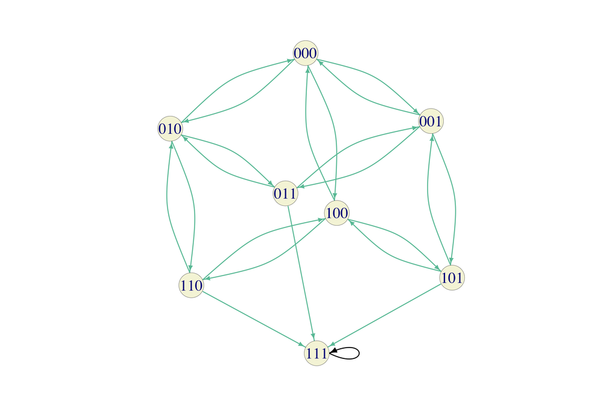

Note: you can call your states whatever you want. Calling them $1,2, \dots, 8$ is a legitimate choice in this case. The reason I chose labels like 001 and 101 is to make it easier to know which pairs of states are neighbors and which are not.

2. All states except for 111 intercommunicate, so they form a class - let’s call it $C_1$. The state 111 is the only element in a separate class $C_2$. The class $C_2$ is clearly recurrent. The class $C_1$ is not because it is not closed. The periods of the states in $C_1$ is two, because the number of 1s in the label of a state changes by 1 (and therefore from even to odd and vice versa) in each step. That means that it is possible to come back only in an even number of steps. Since it is clearly possible to return in exactly $2$ steps, the period must be $2$. The period of 111 is $1$.
3. Here is the code:

   ```r
   S = c("000", "001", "010", "100", "011", "101", "110", "111")

   P = matrix(c(
     0, 1/3, 1/3, 1/3, 0, 0, 0, 0,
     1/3, 0, 0, 0, 1/3, 1/3, 0, 0,
     1/3, 0, 0, 0, 1/3, 0, 1/3, 0,
     1/3, 0, 0, 0, 0, 1/3, 1/3, 0,
     0, 1/3, 1/3, 0, 0, 0, 0, 1/3,
     0, 1/3, 0, 1/3, 0, 0, 0, 1/3,
     0, 0, 1/3, 1/3, 0, 0, 0, 1/3,
     0, 0, 0, 0, 0, 0, 0, 1 ),
    byrow=T, ncol = 8 )
   ```

2. We need to simulate trajectories of our chain first. We reuse the code from the notes:

```r
T = 100 # number of time periods
nsim = 10000 # number of simulations

single_trajectory = function(i) {
  path = numeric(T)
  last = i
  for (n in 1:T) {
    path[n] = sample(1:8, prob=P[last,], size=1)
    last = path[n]
  }
  return(path)
}

i0 = 1 # the initial state is "000" which is at position 1 in S

d = data.frame(
  X0 = i0,
  t(replicate(nsim, single_trajectory(i0)))
)
```

First, we check that all $10000$ trajectories reached the state 8 (i.e., 111) during the first `T=100` steps:

```r
table(d$X100)
```

```
##
##     8
## 10000
```

1. We are going to use the function `match` to find the first time number $8$ appears in each trajectory. We subtract 1 because the problem is asking for the *number of steps* and R starts counting from 1:

```r
tau = apply(d, 1, function(x) match(8,x)-1 )
(mean(tau))
```

```
## [1] 10.091
```

The expected number of steps is about $10$. (We will see later that the exact value of the expectation is precisely $10$.)

2. Here we need to count the number of times the state 1 (the position of 000) appears in each trajectory

```r
number_of_ones = function(x) {
  sum(x==1)
}
noo = apply(d,1,number_of_ones)
(mean(noo))
```

```
## [1] 2.5092
```

So the expected number of times the initial state $1$ is visited is approximately $2.5$.

3. We need to count the number of different values appearing in each trajectory. The R function `unique` removes duplicates, so all we need to do is the following:

```r
number_of_unique_values = function(x) {
  length(unique(x))
}
nouv = apply(d,1,number_of_unique_values)
(mean(nouv))
```

```
## [1] 5.7449
```

Hence, the expected number of different vertices visited by Wonder Woman is about $5.75$.

4. Since all vertices are visited if and only if the number of different vertices visited is $8$, We can reuse the vector `nouv` from c. above:

```r
(mean(nouv==8))
```

```
## [1] 0.1692
```

This means that all vertices will get visited with approximate probability of $0.17$.